# Named and positional arguments

Published

November 16, 2023

```r
library(palmerpenguins)
library(ggplot2)
```

Consider the following code we use to create a scatterplot from the penguin data:

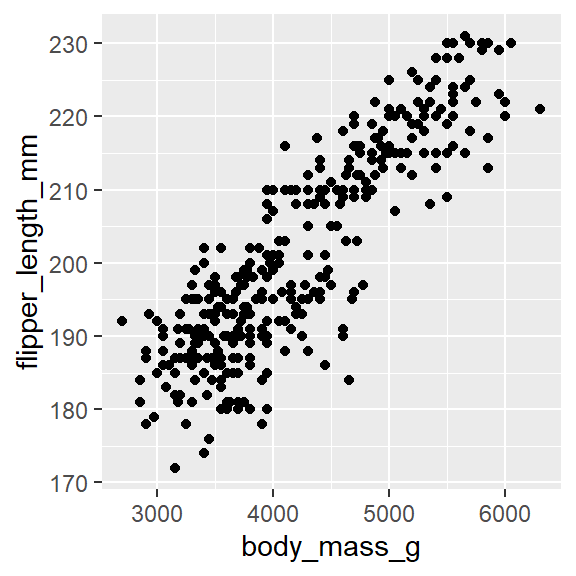

```r
ggplot(data = penguins,
       mapping = aes(x = body_mass_g, y = flipper_length_mm)) +
    geom_point()
```

We use the `data` and `mapping` arguments in the `ggplot()` function to define the input data and the aesthetic mappings, respectively. When constructing this code, we explicitly write the names of arguments (e.g. `data = ...`). This is called using **named arguments**.

Compare this to the following code, which generates the exact same scatterplot:

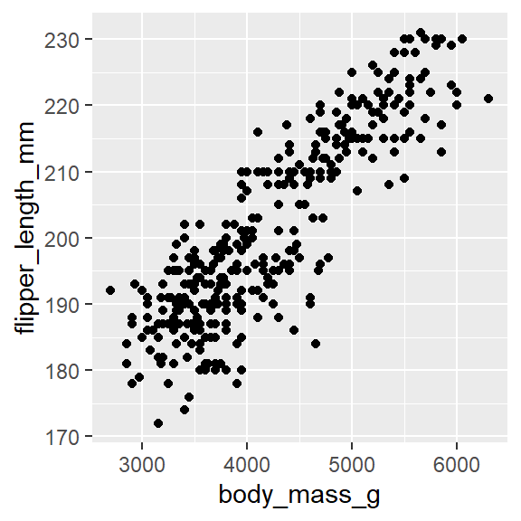

```r
ggplot(penguins,
       aes(x = body_mass_g, y = flipper_length_mm)) +
    geom_point()
```

Why do you think this works? *Hint: look at the ‘Usage’ section on the help page for `ggplot()`*

When we don’t provide the names of arguments, R uses their positions in the function call to identify which values to assign to which argument. This is called using **positional arguments**. You can find the order of arguments that R expects for a function by referring to the help documentation, or by using the `args()` function.

```r
args(ggplot)
```

```
function (data = NULL, mapping = aes(), ..., environment = parent.frame())
NULL
```

Now that we’ve seen the order of the arguments the `ggplot()` function expects, let’s re-examine the second block of code we used to create the scatterplot.

```r
ggplot(penguins,
       aes(x = body_mass_g, y = flipper_length_mm)) +
    geom_point()
```

The first argument the `ggplot()` function expects in the `data` argument. In this code, `penguins` is the first argument we provide. Since we didn’t specify an argument name, R automatically assigns it to the `data` argument. Similarly, the aesthetic mapping (`aes(...)`) is the second argument we provide. Again, we didn’t specify an argument name so R automatically assigns it to `mapping`, the next unused argument in list of arguments returned by the `args(ggplot)`.

Both argument conventions offer advantages. When we use named arguments, we can provide them in any order.

```r
ggplot(mapping = aes(x = body_mass_g, y = flipper_length_mm),
       data = penguins) +
    geom_point()
```

Positional arguments save us some typing and make use more efficient programmers, particularly for functions that we re-use often in our code. For example, since the first argument for most *dplyr* functions is the input data, we tend define the data using a positional argument.

We can also use a mix of named and positional arguments in the same function call:

```r
ggplot(aes(x = body_mass_g, y = flipper_length_mm),
       data = penguins) +
    geom_point()
```

Even though the mapping `aes()` is the first positional argument R assigns it to the `mapping` argument. This is because we’ve explicitly defined the data as a named argument elsewhere in the function call. When R assigns positional arguments, it first assigns all of the named arguments, then assigns positional arguments to whatever is left. In the above example, when R goes to assign the aesthetics it skips the `data` argument, because we define `data` using a named argument, and assigns `aes(...)` to the next `mapping`, which is the next un-used argument after `data`.

Back to top